# Exam_2_Draft

## Info on exam

There will be four different tasks with various sub-tasks and the following points:

1. single choice questions - 30p
2. Code explanation - 18p
3. Regression - 24p
4. Regularization and Generalisability - 18p
- The exam consists of 90p total.
- The pure processing time is 120 minutes
- authorized aids: Dictionary and calculator / zugelassene Hilfsmittel: Wörterbuch und Taschenrechner

  **Note**

  You are free to choose between answering the questions in English OR German, but please stick to one language and do not switch in-between sentences/tasks.
- Be brief, be precise. Only answer the things that are asked. There are no extra points if you write more than required!
- The exam consists of two parts: a multiple choice and a text task part. Both parts must be completed in full.
- Define each abbreviation (e.g. σ) at least once if it is not already predefined!
- You are not supposed to answer with handwritten code but rather with “normal” text.
- Use as many post decimal digits (“Nachkommastellen”) as stated - if NOT stated, use two
- If you need additional space, use the attached empty pages and leave a clear remark at each task, that you used them and where to find your answer(s).

**Important**

If you are not sure on the translation of a certain term from English to German please ask the exam supervisors!

# Task 1: single choice Questions (30p)

10 questions, 3p each!

**Note**

Please note, that exactly one single answers is correct.

## **Task 1.1**

Which of the following statements describes symptoms of **overfitting** in a linear regression model?

1. ⬜ The model performs well on training data but poorly on unseen test data.
2. ⬜ The model has high bias and performs poorly on both training and test data.
3. ⬜ The model performs well on both training and test data.
4. ⬜ The model has low variance and captures no noise in the training data.

## Task 1.2

In the context of data science, which of the following best describes the concept of **generalizability**?

1. ⬜ The ability of a model to perfectly predict the target variable for the training data.
2. ⬜ The ability of a model to identify patterns in a dataset that can be applied to other similar datasets.
3. ⬜ The ability of a model to memorize specific examples from the training data.
4. ⬜ The ability to visualize and interpret the training data in multiple ways.

## Task 1.3

What does the
$$R^2$$
**represent in a linear regression model**?

1. ⬜ The percentage of the total variation in the dependent variable explained by the independent variable(s).
2. ⬜ The strength and direction of the correlation between the dependent and independent variables.
3. ⬜ The average error of the predictions made by the model.
4. ⬜ The proportion of the independent variable’s variance that is unexplained by the model.

## Task 1.4

Which of the following best describes the purpose of a **simple linear regression model?**

1. ⬜ To determine the exact cause of changes in a dependent variable.
2. ⬜ To estimate the relationship between one dependent variable and one independent variable.
3. ⬜ To calculate the mean of a dataset.
4. ⬜ To analyse the relationship between multiple dependent variables.

## Task 1.5

In regularization techniques like Ridge and Lasso regression, what effect does increasing the **regularization parameter** ($\lambda$) have on the model?

1. ⬜ It increases the complexity of the model by allowing larger coefficients.
2. ⬜ It reduces the magnitude of small coefficients, leading to simpler models and less overfitting.
3. ⬜ It has no impact on the model’s coefficients or complexity.
4. ⬜ It increases the model’s sensitivity to noise in the training data.

## Task 1.6

Which of these statements is correct when it comes to the use of **test data and training data in data science**?

1. ⬜ Training data is used to evaluate the performance of the model, while test data is used to train the model.
2. ⬜ Both training and test data should always contain the same data points to make comparisons easier.
3. ⬜ A model is fit on the training set, and the fitted model is used to predict the responses for the observations in the validation set.
4. ⬜ We always train a model on 5% of the data set and validate on 95% of the data for having greater generalization performance.

## Task 1.7

In R, what function is commonly used to **transform data into a data frame**?

1. ⬜ matrix()
2. ⬜ as.data.frame()
3. ⬜ df()
4. ⬜ table()

## Task 1.8

Which package in R is commonly used for creating advanced **graphics**?

1. ⬜ ggplot2
2. ⬜ dplyr
3. ⬜ tidyr
4. ⬜ shiny

## Task 1.9

What does ‘**pruning**’ refer to in the context of decision trees?

1. ⬜ Increasing the number of features considered in the model to provide more complexity.
2. ⬜ Aggregating the results of multiple decision trees into a single model for better accuracy.
3. ⬜ Refining the model by removing branches that do not significantly contribute to predictive power
4. ⬜ Utilizing cross-validation techniques to determine significant branches.

## Task 1.10

After fitting a linear regression model in R using the `lm()` function, you obtain the following output for the model coefficients:

$$\text{(Intercept)} = 5.2, \quad \beta_1 = 2.4, \quad \beta_2 = -0.8$$
Given this model:

$$\hat{y} = 5.2 + 2.4 \times X_1 - 0.8 \times X_2$$

What can be inferred from $\beta_1$ in this model?

1. ⬜ For each unit increase in $X_1$, the predicted value of $y$ will increase by 5.2.
2. ⬜ For each unit increase in $X_1$, the predicted value of $y$ will increase by 2.4, assuming $X_2$ remains constant.
3. ⬜ For each unit increase in $X_2$, the predicted value of $y$ will increase by 0.8, assuming $X_1$ remains constant.
4. ⬜ The value of $y$ is independent of $X_1$ and only depends on $X_2$.

# Task 2: Code interpretation

The dataset `energy` will be used in multiple tasks. In task 2.1 you will clean it, in task 2.2 you will use it in a plotting task.

`energy` includes data on a countries CO2-emissions and related metrics. In the data description you can see the variables meaning and units.

## Data Description

name of the variable

explanation

explanation on unit

**Country**

Country in question

**Energy_type**

Type of energy source

**Year**

Year the data was recorded

**Energy_consumption** -

Amount of Consumption for the specific energy source, measured (quad Btu)

- **Energieeinheit, die 1 Billiarde (10 <sup>15</sup> ) British Thermal Units (BTU) entspricht**
- Unit of energy, equivalent to 1 quadrillion (**10 <sup>15</sup>** ) British Thermal Units (BTU)]

**Energy_production**

Amount of Production for the specific energy source, measured (quad Btu)

- **Energieeinheit, die 1 Billiarde (10 <sup>15</sup> ) British Thermal Units (BTU) entspricht**
- Unit of energy, equivalent to 1 quadrillion (**10 <sup>15</sup>** ) British Thermal Units (BTU)]

**GDP**

Countries GDP at purchasing power parities, measured (Billion 2015$ PPP)

**Population**

Population of specific Country, measured (Mperson)

**Energy_intensity_per_capita**

Energy intensity is a measure of the energy inefficiency of an economy. It is calculated as units of energy per unit of capita (capita = individual person), measured (MMBtu/person)

**Energy_intensity_by_GDP**

Energy intensity is a measure of the energy inefficiency of an economy. It is calculated as units of energy per unit of GDP, measured (1000 Btu/2015$ GDP PPP)

**CO2_emission** -

The amount of C02 emitted, measured (MMtonnes CO2)

## Task 2.1 (12p in total)

Below is a subset of the dataset `energy`. The code to prepare the data for further analysis in task 3. Follow the steps in the code and update the table by hand (8p).

```r
library(dplyr) #responsible for the "filter" command
energy$Country <- as.factor (energy$Country)
energy_2019 <- energy %>%
  filter(Year >= 2019)

energy_2019 <- energy_2019 %>%
  filter(Energy_type == "all_energy_types")

energy_2019 <- energy_2019 %>%
  filter(Country != "World")

energy_clean_2019 <- na.omit(energy_2019)
```

**2.1.2. Did you remove singular values and/or rows and/or columns? If you did so, explain why. (2p)**

> 3P for removal of observations prior to 2019 - row-removal

> 2P for removal of energy type coal - row-removal

> 1P for removal of “World”-row

> 2P for removal of NA-rows

**2.1.3. After applying the code: Are any values left that could potentially lead to problems? If so, how could we fix that problem (answer verbally, no code needed)? (2p)**

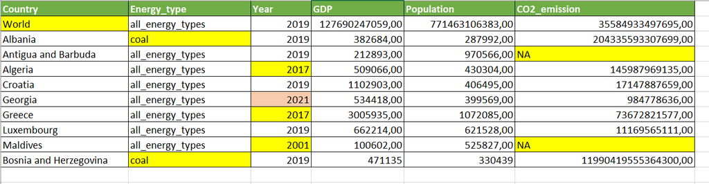

## Task 2.2 (6p in total)

Task 2.2 (3p) What kind of plot gets generated by this code? Choose the correct one below and justify your decision.

```r
library(ggplot2)
library(dplyr)

ggplot(data=energy_clean_2019, mapping=aes(x=Energy_intensity_per_capita,y=CO2_emission)) +
  geom_point() +
  geom_smooth(method = lm) +
 scale_x_continuous(breaks = seq(0, 400, by = 50), limits = c(0,400)) +
scale_y_continuous(breaks = seq(0, 200, by = 50), limits = c(0, 200))
```

Plot 1

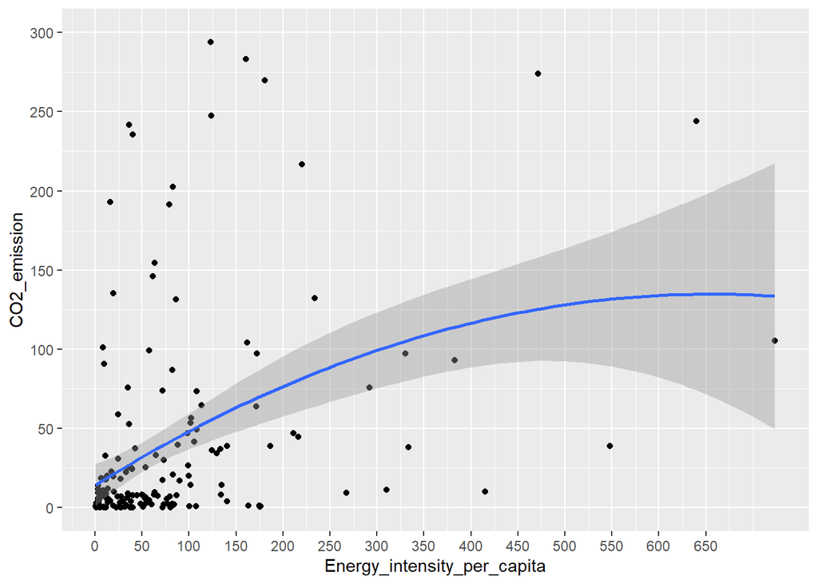

Plot 2

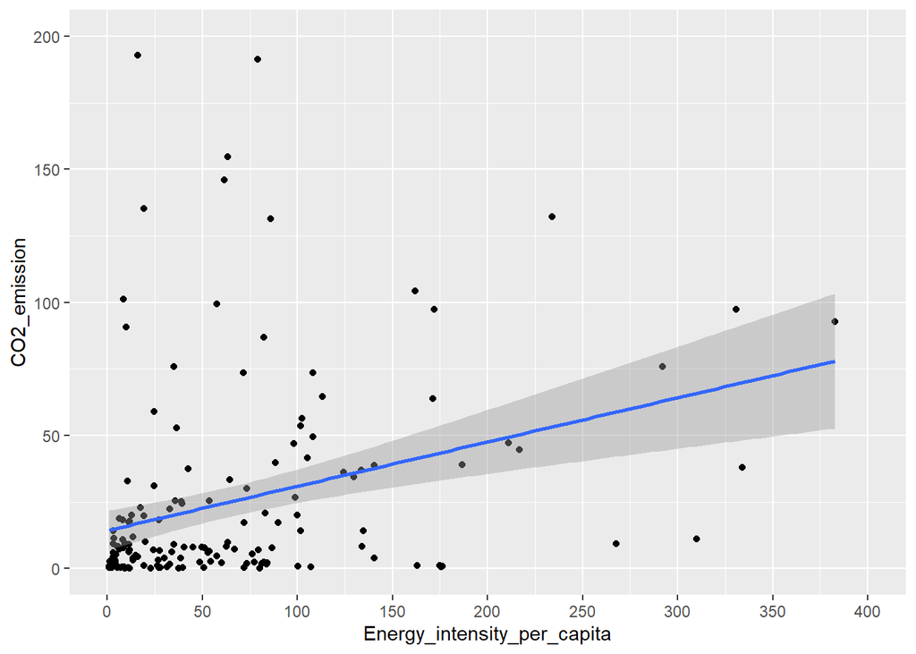

Plot 3

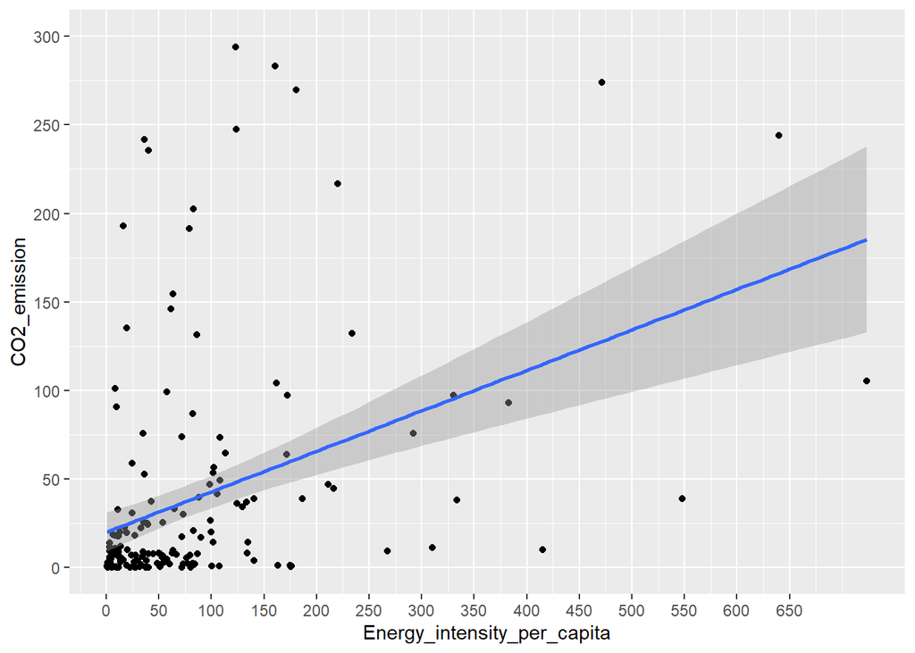

Plot 4

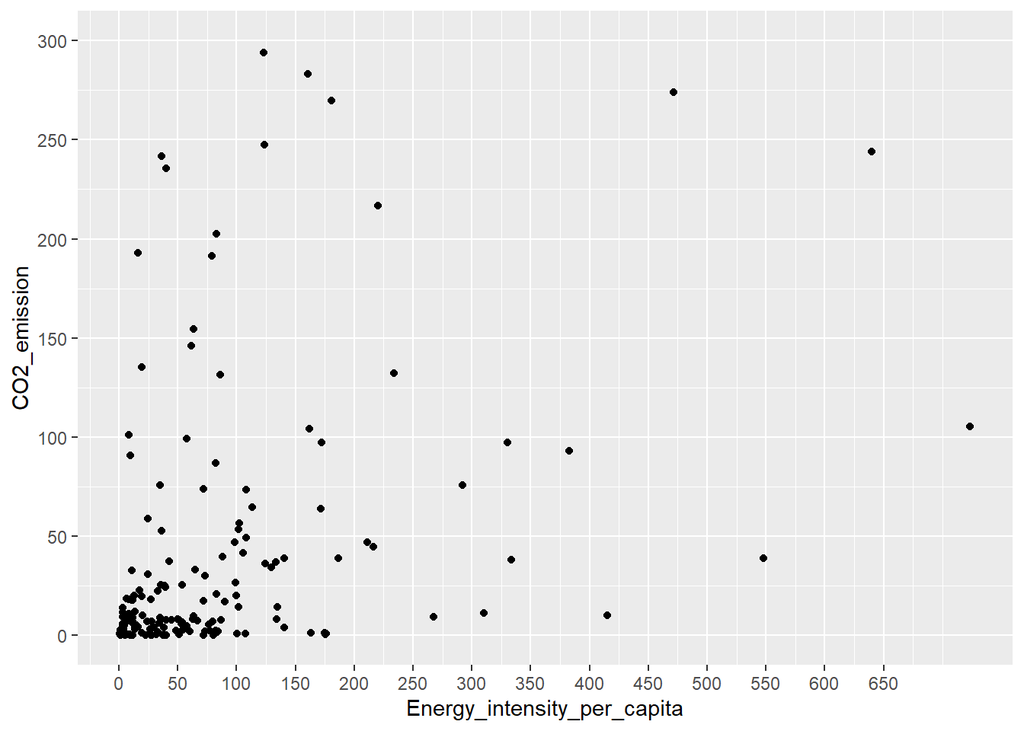